# LAB 3 : Thomas LAVIGNE, Lutèce BILOT & Younes SIYAR

```python
import numpy as np
import matplotlib.pyplot as plt
import pandas as pd
from scipy.optimize import minimize
from scipy.stats import expon, norm, probplot
from scipy.stats import kstest
from scipy.stats import ks_2samp
import time
import os
import pickle

np.random.seed(42)
```

## Paramètres utilisés pour le TP

```python
MU_TRUE = 1.2
ALPHA_TRUE = 0.6
BETA_TRUE = 0.8
THETA_TRUE = np.array([MU_TRUE, ALPHA_TRUE, BETA_TRUE])
PNAMES = [r"$\mu$", r"$\alpha$", r"$\beta$"]
T_VALS = [100, 200, 500, 1000, 2000, 5000]
N_SIM = 200
T_BENCH = [25, 50, 100, 200, 500, 1000]
N_BENCH = 5
T_Q3 = 2000
N_REP_Q3 = 50
```

```python
def compute_R(events, beta):
    n = len(events)
    R = np.zeros(n)
    for i in range(1, n):
        dt = events[i] - events[i - 1]
        R[i] = np.exp(-beta * dt) * (1.0 + R[i - 1])
    return R


def compute_W(events, R, beta):
    n = len(events)
    W = np.zeros(n)
    for i in range(1, n):
        dt = events[i] - events[i - 1]
        W[i] = (
            dt * R[i]
            + np.exp(-beta * dt) * W[i - 1]
        )
    return W


def log_lik(params, events, T):
    mu, alpha, beta = params
    if mu <= 0 or alpha <= 0 or beta <= 0:
        return -np.inf
    n = len(events)
    if n == 0:
        return -mu * T
    R = compute_R(events, beta)
    lam = mu + alpha * R
    if np.any(lam <= 0):
        return -np.inf
    return (
        -mu * T
        - (alpha / beta) * np.sum(
            1.0 - np.exp(-beta * (T - events))
        )
        + np.sum(np.log(lam))
    )


def mle_fit(events, T, x0=None):
    n = len(events)
    if x0 is None:
        r = max(n / T, 0.1)
        x0 = [r * 0.4, 0.4, 1.0]
    res = minimize(
        lambda p: -log_lik(p, events, T),
        x0,
        method="L-BFGS-B",
        bounds=[(1e-8, None)] * 3,
        options={"ftol": 1e-12, "gtol": 1e-8},
    )
    return res.x


def sim_efficient(mu, alpha, beta, T):
    events = []
    t, ls, R = 0.0, mu, 0.0
    while t < T:
        u = np.random.exponential(1.0 / ls)
        tc = t + u
        if tc >= T:
            break
        R = np.exp(-beta * (tc - t)) * R
        lt = mu + alpha * R
        if np.random.uniform() <= lt / ls:
            R += 1.0
            ls = mu + alpha * R
            events.append(tc)
        else:
            ls = lt
        t = tc
    return np.array(events)


def sim_naive(mu, alpha, beta, T):
    events = []
    t, ls = 0.0, mu
    while t < T:
        u = np.random.exponential(1.0 / ls)
        tc = t + u
        if tc >= T:
            break
        ea = np.array(events)
        lt = (
            mu
            + alpha * np.sum(
                np.exp(-beta * (tc - ea))
            )
            if len(ea) > 0
            else mu
        )
        if np.random.uniform() <= lt / ls:
            events.append(tc)
            ls = lt + alpha
        else:
            ls = lt
        t = tc
    return np.array(events)


def sim_branching(mu, alpha, beta, T):
    imm = np.random.uniform(
        0, T, np.random.poisson(mu * T)
    )
    ev = list(imm)
    gen = list(imm)
    while gen:
        nxt = []
        for p in gen:
            nc = np.random.poisson(alpha / beta)
            if nc > 0:
                ch = p + np.random.exponential(
                    1.0 / beta, nc
                )
                ch = ch[ch < T].tolist()
                nxt.extend(ch)
                ev.extend(ch)
        gen = nxt
    return np.sort(np.array(ev))


def sim_powerlaw(mu, alpha, p_exp, T):
    events = []
    t, ls = 0.0, mu
    while t < T:
        u = np.random.exponential(1.0 / ls)
        tc = t + u
        if tc >= T:
            break
        ea = np.array(events)
        lt = (
            mu
            + alpha
            * np.sum((1.0 + tc - ea) ** (-p_exp))
            if len(ea) > 0
            else mu
        )
        if np.random.uniform() <= lt / ls:
            events.append(tc)
            ls = lt + alpha
        else:
            ls = lt
        t = tc
    return np.array(events)

def sim_p_expo(mu, alphas, betas, T):
    alphas_arr = np.array(alphas, dtype=float)
    betas_arr  = np.array(betas,  dtype=float)
    events = []
    t, Rs = 0.0, np.zeros(len(alphas_arr))
    ls = float(mu)
    while t < T:
        u  = np.random.exponential(1.0 / ls)
        tc = t + u
        if tc >= T:
            break
        dt = tc - t
        Rs = np.exp(-betas_arr * dt) * Rs
        lt = mu + float(np.dot(alphas_arr, Rs))
        if np.random.uniform() <= lt / ls:
            Rs += 1.0
            ls  = mu + float(np.dot(alphas_arr, Rs))
            events.append(tc)
        else:
            ls = lt
        t = tc
    return np.array(events)

def em_fit(events, T, max_iter=2000, tol=1e-10):
    n = len(events)
    mu, alpha, beta = n / T * 0.3, 0.3, 1.0
    hist = [[mu, alpha, beta]]
    for _ in range(max_iter):
        R = compute_R(events, beta)
        W = compute_W(events, R, beta)
        li = mu + alpha * R
        pii = mu / li
        S1 = np.sum(alpha * R / li)
        S2 = np.sum(alpha * W / li)
        et = np.exp(-beta * (T - events))
        da = np.sum(1.0 - et)
        bt = np.sum((T - events) * et)
        mu_n = np.sum(pii) / T
        an = beta * S1 / da if da > 1e-10 else alpha
        db = S2 + S1 * bt / da
        bn = S1 / db if db > 1e-10 else beta
        delta = np.linalg.norm([mu_n - mu, an - alpha, bn - beta])
        mu, alpha, beta = mu_n, an, bn
        hist.append([mu, alpha, beta])
        if delta < tol:
            break
    return mu, alpha, beta, np.array(hist)


def get_compensators(events, mu, alpha, beta):
    C = []
    A, prev = 0.0, 0.0
    for ti in events:
        dt = ti - prev
        C.append(
            mu * dt
            + (alpha / beta)
            * (1.0 - np.exp(-beta * dt))
            * A
        )
        A = 1.0 + np.exp(-beta * dt) * A
        prev = ti
    return np.array(C)
```

## Question I - Properties of Hawkes MLE estimates.

Pour cette question nous considérons un processus de Hawkes d'intensité $\mu = 1.2$ et de noyau $\nu(t) = 0.6*\exp(-0.8*t)$.

L'idée est de vérifier que notre estimateur MLE vérifie certaines propriétés statistiques.

On simule `N_SIM` = 200 réalisations du processus par l'algorithme de thinning pour différents horizons ($T \in \{100, \dots, 5000\}$), puis on calcule l'estimateur MLE par maximisation numérique de la log-vraisemblance. On vérifie les propriétés suivantes :

- **Consistance** : la moyenne des estimées converge vers les vraies valeurs quand $T \to \infty$.
- **Normalité asymptotique** : $\sqrt{T}(\hat{\theta} - \theta^*) \to \mathcal{N}(0, I^{-1}(\theta^*))$, vérifiée par histogramme.
- **Efficacité asymptotique** : $std(\hat{\theta}) \propto \frac{1}{\sqrt{T}}$ sur l'échelle log-log.
- **Goodness-of-fit** : les compensateurs $\Lambda(t_{i-1}, t_i)$ doivent être i.i.d. $\mathcal{E}xp(1)$, visualisé via Q-Q plot.

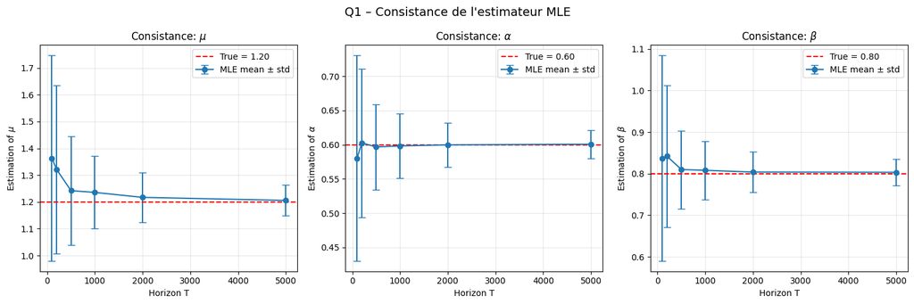

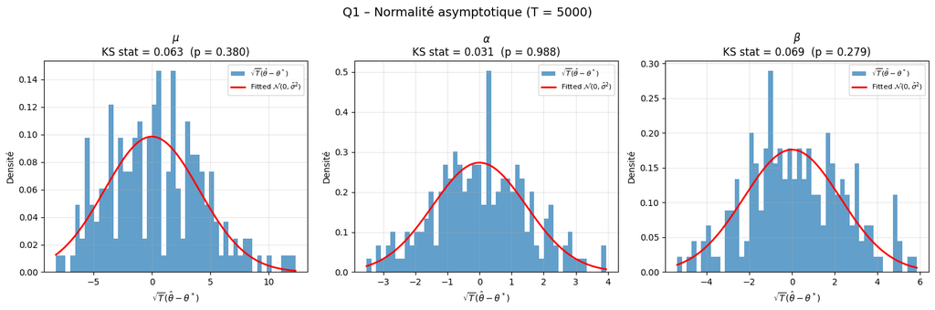

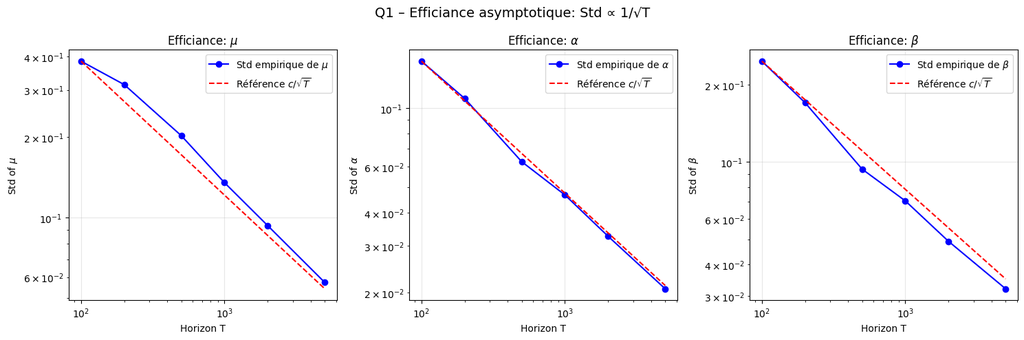

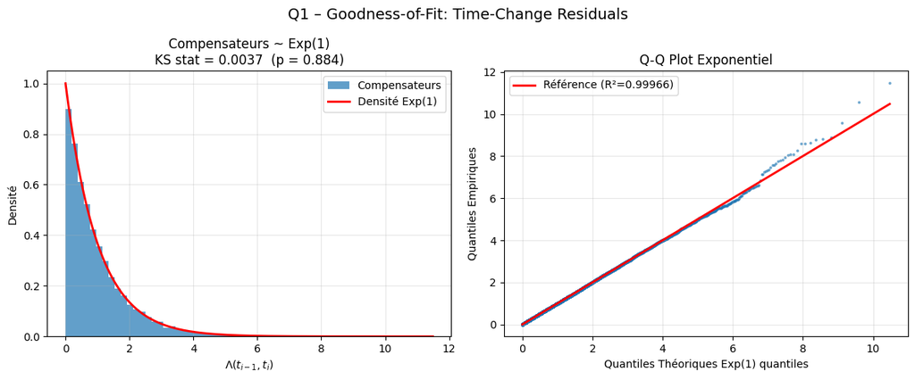

```python
CACHE_Q1 = "DHF-LAB3-BILOT-LAVIGNE-SIYAR_q1_ests.npy"
if not os.path.exists(CACHE_Q1):
    ests = np.full((len(T_VALS), N_SIM, 3), np.nan)
    for i, T in enumerate(T_VALS):
        for k in range(N_SIM):
            ev = sim_efficient(MU_TRUE, ALPHA_TRUE, BETA_TRUE, T)
            try:
                ests[i, k] = mle_fit(ev, T)
            except Exception:
                pass
    np.save(CACHE_Q1, ests)

ests  = np.load(CACHE_Q1)
means = np.nanmean(ests, axis=1)
stds  = np.nanstd(ests,  axis=1)
T_arr = np.array(T_VALS, dtype=float)

fig, axes = plt.subplots(1, 3, figsize=(15, 5))
fig.suptitle("Q1 – Consistance de l'estimateur MLE", fontsize=14)
for k, ax in enumerate(axes):
    ax.errorbar(T_arr, means[:, k], yerr=stds[:, k],
                fmt="o-", capsize=4, label="MLE mean ± std")
    ax.axhline(THETA_TRUE[k], color="r", ls="--",
               label=f"True = {THETA_TRUE[k]:.2f}")
    ax.set_xlabel("Horizon T")
    ax.set_ylabel(f"Estimation of {PNAMES[k]}")
    ax.set_title(f"Consistance: {PNAMES[k]}")
    ax.legend()
    ax.grid(True, alpha=0.3)
plt.tight_layout()
plt.show()

T_l = T_VALS[-1]
e_l = ests[-1]
e_l = e_l[~np.any(np.isnan(e_l), axis=1)]

fig, axes = plt.subplots(1, 3, figsize=(15, 5))
fig.suptitle(f"Q1 – Normalité asymptotique (T = {T_l})", fontsize=14)
for k, ax in enumerate(axes):
    sc = np.sqrt(T_l) * (e_l[:, k] - THETA_TRUE[k])
    stat_ks, pval_ks = kstest(sc, "norm", args=(0.0, sc.std()))
    ax.hist(sc, bins=50, density=True, alpha=0.7,
            label=r"$\sqrt{T}(\hat{\theta}-\theta^*)$")
    xs = np.linspace(sc.min(), sc.max(), 300)
    ax.plot(xs, norm.pdf(xs, 0.0, sc.std()), "r-", lw=2,
            label=r"Fitted $\mathcal{N}(0,\hat{\sigma}^2)$")
    ax.set_xlabel(r"$\sqrt{T}(\hat{\theta} - \theta^*)$")
    ax.set_ylabel("Densité")
    ax.set_title(f"{PNAMES[k]}\nKS stat = {stat_ks:.3f}  (p = {pval_ks:.3f})")
    ax.legend(fontsize=8)
    ax.grid(True, alpha=0.3)
plt.tight_layout()
plt.show()

fig, axes = plt.subplots(1, 3, figsize=(15, 5))
fig.suptitle("Q1 – Efficiance asymptotique: Std ∝ 1/√T", fontsize=14)
for k, ax in enumerate(axes):
    ax.plot(T_arr, stds[:, k], "bo-", label=f"Std empirique de {PNAMES[k]}")
    c = stds[0, k] * np.sqrt(T_VALS[0])
    ax.plot(T_arr, c / np.sqrt(T_arr), "r--", label=r"Référence $c/\sqrt{T}$")
    ax.set_xscale("log"); ax.set_yscale("log")
    ax.set_xlabel("Horizon T"); ax.set_ylabel(f"Std of {PNAMES[k]}")
    ax.set_title(f"Efficiance: {PNAMES[k]}")
    ax.legend(); ax.grid(True, alpha=0.3)
plt.tight_layout()
plt.show()

ev_gof = sim_efficient(MU_TRUE, ALPHA_TRUE, BETA_TRUE, 5000)
th_gof = mle_fit(ev_gof, 5000)
C_gof  = get_compensators(ev_gof, *th_gof)

stat_ks_gof, pval_ks_gof = kstest(C_gof, "expon")

fig, axes = plt.subplots(1, 2, figsize=(12, 5))
fig.suptitle("Q1 – Goodness-of-Fit: Time-Change Residuals", fontsize=14)

axes[0].hist(C_gof, bins=60, density=True, alpha=0.7, label="Compensateurs")
xs = np.linspace(0, C_gof.max(), 300)
axes[0].plot(xs, expon.pdf(xs), "r-", lw=2, label="Densité Exp(1)")
axes[0].set_xlabel(r"$\Lambda(t_{i-1}, t_i)$"); axes[0].set_ylabel("Densité")
axes[0].set_title(
    f"Compensateurs ~ Exp(1)\nKS stat = {stat_ks_gof:.4f}  (p = {pval_ks_gof:.3f})"
)
axes[0].legend(); axes[0].grid(True, alpha=0.3)

r_qq = probplot(C_gof, dist="expon")
osm, osr = r_qq[0]; slope, intercept, r_val = r_qq[1]
axes[1].scatter(osm, osr, s=3, alpha=0.5)
axes[1].plot(osm, slope * osm + intercept, "r-", lw=2,
             label=f"Référence (R²={r_val**2:.5f})")
axes[1].set_xlabel("Quantiles Théoriques Exp(1) quantiles")
axes[1].set_ylabel("Quantiles Empiriques")
axes[1].set_title("Q-Q Plot Exponentiel")
axes[1].legend(); axes[1].grid(True, alpha=0.3)
plt.tight_layout()
plt.show()
```

### Analyse

**Consistance** : Les trois estimateurs convergent bien vers les vraies valeurs ($\mu=1.2, \alpha=0.6, \beta=0.8$) quand T augmente. Les barres d'erreur se resserrent nettement, ce qui confirme la consistance du MLE.

**Normalité asymptotique** : À T=5000, les histogrammes de $\sqrt{T}(\hat{\theta} - \theta^*)$ s'approchent visuellement d'une gaussienne centrée. Les tests KS confirment qu'on ne peut pas rejeter la normalité ($p=0.38$ pour $\mu, p=0.98$ pour $\alpha, p=0.28$ pour $\beta$). Les p-values sur $\mu$ et $\beta$ sont un peu faibles, ce qui peut s'expliquer par le fait que `N_SIM`=200 reste modeste pour estimer précisément les queues de distribution.

**Efficacité asymptotique** : En log-log, les courbes empiriques sont parallèles à la référence $c/\sqrt{T}$, ce qui valide que la variance décroît bien en O(1/T). La MLE est donc asymptotiquement efficace.

**Goodness-of-fit** : Les compensateurs $\Lambda(t_{i-1}, t_i) $ suivent très bien une Exp(1). En effet le Q-Q plot est quasi-parfait (R²=0.9996) et le test KS donne p=0.88.

## Question II - Computational cost of Hawkes simulators.

Pour cette question, on va comparer les algorithmes selon deux axes indépendants : l'algorithme de simulation et le choix du kernel

### Partie B – Comparaison de kernels sur le thinning efficient

Pour ce test, on fixe l'algorithme (thinning efficient) et on compare :

- **Kernel 1-exponentiel** : $\nu(t) = \alpha e^{-\beta t}$, récurrence scalaire, **$O(n)$**.
- **Kernel $P$-exponentiel** : $\nu(t) = \sum_{j=1}^P \alpha_j e^{-\beta_j t}$, $P$ récurrences parallèles, **$O(n \cdot P)$**.
- **Power-law** : $\nu(t) = \alpha(1+t)^{-p}$, pas de récurrence possible : **$O(n^2)$**.

Afin de valider que nos simulateurs sont corrects, on vérifie au préalable la propriété suivante : $\mathbb{E}[N(T)]$ observé $\approx \frac{\mu T}{1 - \alpha/\beta}$ pour les 3 algorithmes.

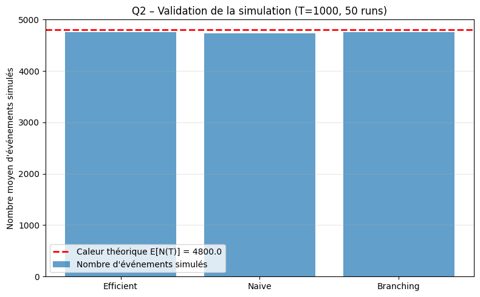

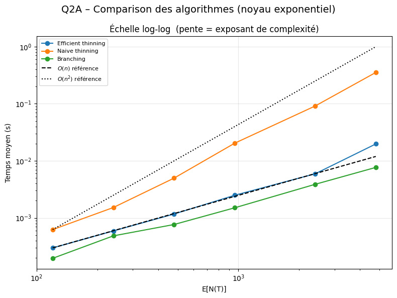

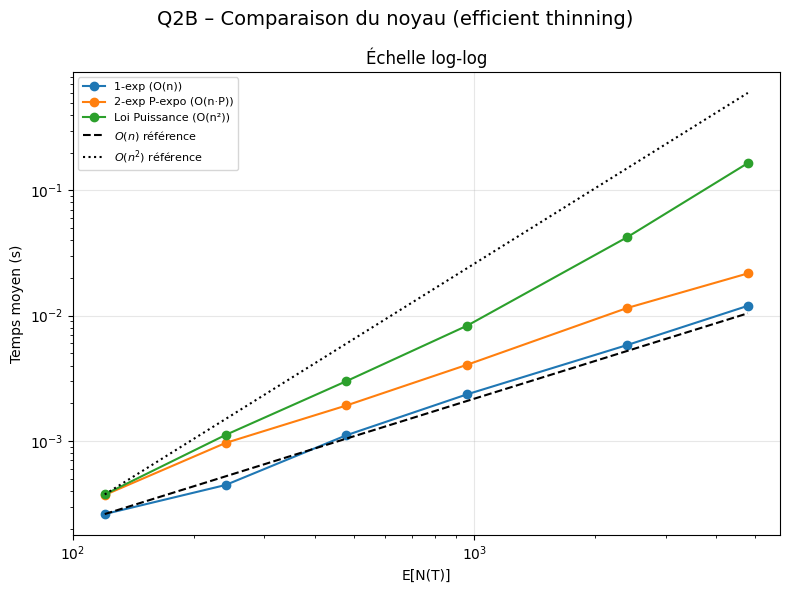

```python
def _bench(func, T_list, n_bench):
    times = []
    for T_ in T_list:
        runs = []
        for _ in range(n_bench):
            t0 = time.perf_counter()
            func(T_)
            runs.append(time.perf_counter() - t0)
        times.append(np.mean(runs))
    return times

def _validate_simulators():
    T_val, n_runs = 1000, 50
    expected_n = MU_TRUE * T_val / (1.0 - ALPHA_TRUE / BETA_TRUE)
    funcs = {
        "Efficient":  lambda: sim_efficient(MU_TRUE, ALPHA_TRUE, BETA_TRUE, T_val),
        "Naive":      lambda: sim_naive(MU_TRUE, ALPHA_TRUE, BETA_TRUE, T_val),
        "Branching":  lambda: sim_branching(MU_TRUE, ALPHA_TRUE, BETA_TRUE, T_val),
    }
    return (
        {k: np.mean([len(f()) for _ in range(n_runs)]) for k, f in funcs.items()},
        expected_n,
    )

val_results, expected_n_val = _validate_simulators()
fig, ax = plt.subplots(figsize=(8, 5))
ax.bar(list(val_results.keys()), list(val_results.values()),
       alpha=0.7, label="Nombre d'événements simulés")
ax.axhline(expected_n_val, color="r", ls="--", lw=2,
           label=f"Caleur théorique E[N(T)] = {expected_n_val:.1f}")
ax.set_ylabel("Nombre moyen d'événements simulés")
ax.set_title("Q2 – Validation de la simulation (T=1000, 50 runs)")
ax.legend(); ax.grid(True, alpha=0.3, axis="y")
plt.tight_layout()
plt.show()

avg_n = np.array(T_BENCH, dtype=float) * (MU_TRUE / (1.0 - ALPHA_TRUE / BETA_TRUE))

CACHE_Q2A = "DHF-LAB3-BILOT-LAVIGNE-SIYAR_q2_algos.pkl"
if not os.path.exists(CACHE_Q2A):
    algos_exp = {
        "Efficient thinning": lambda T_: sim_efficient(MU_TRUE, ALPHA_TRUE, BETA_TRUE, T_),
        "Naive thinning":     lambda T_: sim_naive(MU_TRUE, ALPHA_TRUE, BETA_TRUE, T_),
        "Branching":          lambda T_: sim_branching(MU_TRUE, ALPHA_TRUE, BETA_TRUE, T_),
    }
    times_algos = {k: _bench(f, T_BENCH, N_BENCH) for k, f in algos_exp.items()}
    with open(CACHE_Q2A, "wb") as fh:
        pickle.dump(times_algos, fh)
with open(CACHE_Q2A, "rb") as fh:
    times_algos = pickle.load(fh)

t_eff = np.array(times_algos["Efficient thinning"])
t_nai = np.array(times_algos["Naive thinning"])

fig, ax = plt.subplots(figsize=(8, 6))
fig.suptitle("Q2A – Comparison des algorithmes (noyau exponentiel)", fontsize=14)
for name, vals in times_algos.items():
    ax.plot(avg_n, vals, "o-", label=name)
ax.plot(avg_n, t_eff[0] * avg_n / avg_n[0],
        "k--", lw=1.5, label=r"$O(n)$ référence")
ax.plot(avg_n, t_nai[0] * (avg_n / avg_n[0])**2,
        "k:",  lw=1.5, label=r"$O(n^2)$ référence")
ax.set_xscale("log"); ax.set_yscale("log")
ax.set_xlabel("E[N(T)]"); ax.set_ylabel("Temps moyen (s)")
ax.set_title("Échelle log-log  (pente = exposant de complexité)")
ax.legend(fontsize=8); ax.grid(True, alpha=0.3)
plt.tight_layout()
plt.show()

ALPHAS_P = [0.3, 0.3]
BETAS_P  = [0.6, 1.2]
ALPHA_PL, P_EXP_PL = 0.6, 2.0

CACHE_Q2B = "DHF-LAB3-BILOT-LAVIGNE-SIYAR_q2_kernels.pkl"
if not os.path.exists(CACHE_Q2B):
    kernels = {
        "1-exp (O(n))":       lambda T_: sim_efficient(MU_TRUE, ALPHA_TRUE, BETA_TRUE, T_),
        "2-exp P-expo (O(n·P))": lambda T_: sim_p_expo(MU_TRUE, ALPHAS_P, BETAS_P, T_),
        "Loi Puissance (O(n²))":  lambda T_: sim_powerlaw(MU_TRUE, ALPHA_PL, P_EXP_PL, T_),
    }
    times_kernels = {k: _bench(f, T_BENCH, N_BENCH) for k, f in kernels.items()}
    with open(CACHE_Q2B, "wb") as fh:
        pickle.dump(times_kernels, fh)
with open(CACHE_Q2B, "rb") as fh:
    times_kernels = pickle.load(fh)

t_1exp = np.array(times_kernels["1-exp (O(n))"])
t_pl   = np.array(times_kernels["Loi Puissance (O(n²))"])

fig, ax = plt.subplots(figsize=(8, 6))
fig.suptitle("Q2B – Comparaison du noyau (efficient thinning)", fontsize=14)
for name, vals in times_kernels.items():
    ax.plot(avg_n, vals, "o-", label=name)
ax.plot(avg_n, t_1exp[0] * avg_n / avg_n[0],
        "k--", lw=1.5, label=r"$O(n)$ référence")
ax.plot(avg_n, t_pl[0] * (avg_n / avg_n[0])**2,
        "k:",  lw=1.5, label=r"$O(n^2)$ référence")
ax.set_xscale("log"); ax.set_yscale("log")
ax.set_xlabel("E[N(T)]"); ax.set_ylabel("Temps moyen (s)")
ax.set_title("Échelle log-log")
ax.legend(fontsize=8); ax.grid(True, alpha=0.3)
plt.tight_layout()
plt.show()
```

### Analyse

**Validation** : Les trois simulateurs (efficient, naive, branching) produisent un nombre moyen d'événements très proche de la valeur théorique. Les simulateurs semblent donc correctement implémentés.

**Q2A - Comparaison d'algorithmes (kernel exponentiel)** : En log-log, le thinning efficient suit parfaitement la référence $O(n)$ (pente bleue). Le thinning naïf présente une pente plus élevée, proche de $O(n^2)$ (pente orange), ce qui s'explique par la re-somme complète $\sum_{k<i} \alpha e^{-\beta(t_i - t_k)}$ à chaque événement. Le branching affiche également une pente légèrement en dessous de $O(n)$ (pente verte).

**Q2B - Comparaison de kernels (thinning efficient)** : Le kernel 1-exponentiel est le plus rapide : la récurrence sur $R(i) = e^{-\beta \Delta t}(1 + R(i-1))$ réduit le coût à $O(n)$. Le kernel P-exponentiel ($P=2$) suit la même pente $O(n)$ mais avec une constante multipliée par $P$, ce qui se voit clairement comme un décalage vertical sur le graphe log-log. Le power-law $\nu(t) = \alpha(1+t)^{-p}$ ne dispose d'aucune récurrence : il faut recalculer $\sum_{k<i}(1 + t_i - t_k)^{-p}$ entièrement, d'où un coût théorique de $O(n^2)$ (qui se confirme plus ou moins par la pente observée).

## Question III - MLE vs EM estimation.

Pour comparer les estimations MLE et EM d'un processus de Hawke, on réalise 50 réalisations avec un horizon de 2000 (T=2000). On compare :

- Distributions des estimées et biais via la **MSE**.
- Temps de calcul.
- Convergence des itérations EM (trajectoire vers MLE et vraies valeurs).
- Qualité d'ajustement : Q-Q plot des compensateurs + test KS pour Exp(1).

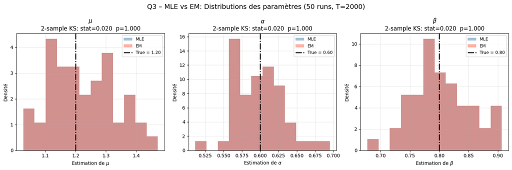

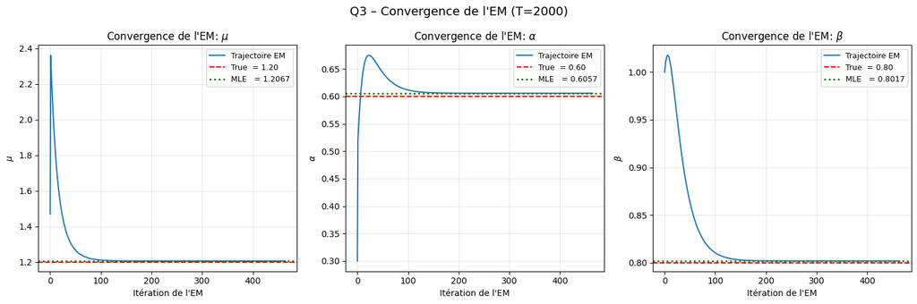

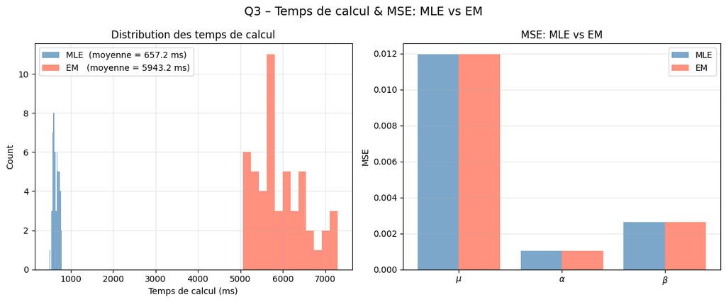

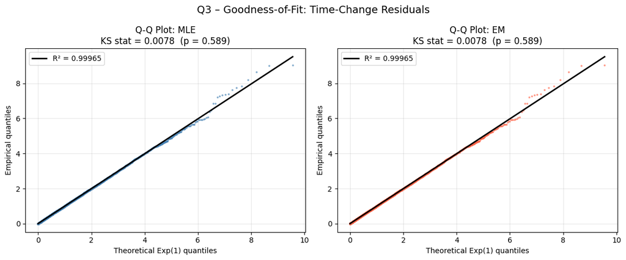

```python
CACHE_Q3 = "DHF-LAB3-BILOT-LAVIGNE-SIYAR_q3_comparison.pkl"
if not os.path.exists(CACHE_Q3):
    mle_reps = np.zeros((N_REP_Q3, 3))
    em_reps  = np.zeros((N_REP_Q3, 3))
    time_mle_reps = np.zeros(N_REP_Q3)
    time_em_reps  = np.zeros(N_REP_Q3)
    hist_em_single = ev_single = None
    for i in range(N_REP_Q3):
        ev_i = sim_efficient(MU_TRUE, ALPHA_TRUE, BETA_TRUE, T_Q3)
        t0 = time.perf_counter()
        mle_reps[i] = mle_fit(ev_i, T_Q3)
        time_mle_reps[i] = time.perf_counter() - t0
        t0 = time.perf_counter()
        mu_i, a_i, b_i, h_i = em_fit(ev_i, T_Q3)
        time_em_reps[i] = time.perf_counter() - t0
        em_reps[i] = [mu_i, a_i, b_i]
        if i == 0:
            hist_em_single, ev_single = h_i, ev_i
    with open(CACHE_Q3, "wb") as fh:
        pickle.dump((mle_reps, em_reps, time_mle_reps, time_em_reps,
                     hist_em_single, ev_single), fh)

with open(CACHE_Q3, "rb") as fh:
    (mle_reps, em_reps, time_mle_reps, time_em_reps,
     hist_em_single, ev_single) = pickle.load(fh)

fig, axes = plt.subplots(1, 3, figsize=(15, 5))
fig.suptitle(f"Q3 – MLE vs EM: Distributions des paramètres ({N_REP_Q3} runs, T={T_Q3})",
             fontsize=14)
for k, ax in enumerate(axes):
    ax.hist(mle_reps[:, k], bins=12, alpha=0.5, density=True,
            label="MLE", color="steelblue")
    ax.hist(em_reps[:, k],  bins=12, alpha=0.5, density=True,
            label="EM",  color="tomato")
    ax.axvline(THETA_TRUE[k], color="k", lw=2, ls="-.",
               label=f"True = {THETA_TRUE[k]:.2f}")

    stat_2s, pval_2s = ks_2samp(mle_reps[:, k], em_reps[:, k])
    ax.set_xlabel(f"Estimation de {PNAMES[k]}")
    ax.set_ylabel("Densité")
    ax.set_title(f"{PNAMES[k]}\n2-sample KS: stat={stat_2s:.3f}  p={pval_2s:.3f}")
    ax.legend(fontsize=9); ax.grid(True, alpha=0.3)
plt.tight_layout()
plt.show()

hist_arr = np.array(hist_em_single)
theta_mle_single = mle_fit(ev_single, T_Q3)

fig, axes = plt.subplots(1, 3, figsize=(15, 5))
fig.suptitle(f"Q3 – Convergence de l'EM (T={T_Q3})", fontsize=14)
for k, ax in enumerate(axes):
    ax.plot(range(len(hist_arr)), hist_arr[:, k], lw=1.5, label="Trajectoire EM")
    ax.axhline(THETA_TRUE[k], color="r", ls="--",
               label=f"True  = {THETA_TRUE[k]:.2f}")
    ax.axhline(theta_mle_single[k], color="g", ls=":", lw=2,
               label=f"MLE   = {theta_mle_single[k]:.4f}")
    ax.set_xlabel("Itération de l'EM"); ax.set_ylabel(PNAMES[k])
    ax.set_title(f"Convergence de l'EM: {PNAMES[k]}")
    ax.legend(fontsize=9); ax.grid(True, alpha=0.3)
plt.tight_layout()
plt.show()

fig, axes = plt.subplots(1, 2, figsize=(12, 5))
fig.suptitle("Q3 – Temps de calcul & MSE: MLE vs EM", fontsize=14)

axes[0].hist(time_mle_reps * 1000, bins=12, alpha=0.7, color="steelblue",
             label=f"MLE  (moyenne = {time_mle_reps.mean()*1000:.1f} ms)")
axes[0].hist(time_em_reps  * 1000, bins=12, alpha=0.7, color="tomato",
             label=f"EM   (moyenne = {time_em_reps.mean()*1000:.1f} ms)")
axes[0].set_xlabel("Temps de calcul (ms)"); axes[0].set_ylabel("Count")
axes[0].set_title("Distribution des temps de calcul")
axes[0].legend(); axes[0].grid(True, alpha=0.3)

mse_mle = np.mean((mle_reps - THETA_TRUE)**2, axis=0)
mse_em  = np.mean((em_reps  - THETA_TRUE)**2, axis=0)
x_pos = np.arange(3)
axes[1].bar(x_pos - 0.2, mse_mle, width=0.4, alpha=0.7, color="steelblue", label="MLE")
axes[1].bar(x_pos + 0.2, mse_em,  width=0.4, alpha=0.7, color="tomato",    label="EM")
axes[1].set_xticks(x_pos); axes[1].set_xticklabels(PNAMES)
axes[1].set_ylabel("MSE"); axes[1].set_title("MSE: MLE vs EM")
axes[1].legend(); axes[1].grid(True, alpha=0.3, axis="y")
plt.tight_layout()
plt.show()

theta_em_single = hist_arr[-1]
C_mle = get_compensators(ev_single, *theta_mle_single)
C_em  = get_compensators(ev_single, *theta_em_single)

fig, axes = plt.subplots(1, 2, figsize=(12, 5))
fig.suptitle("Q3 – Goodness-of-Fit: Time-Change Residuals", fontsize=14)
for ax, C, label, col in zip(
    axes, [C_mle, C_em], ["MLE", "EM"], ["steelblue", "tomato"]
):
    stat_ks, pval_ks = kstest(C, "expon")
    r_q = probplot(C, dist="expon")
    osm_q, osr_q = r_q[0]; sl, ic, rv = r_q[1]
    ax.scatter(osm_q, osr_q, s=3, alpha=0.5, color=col)
    ax.plot(osm_q, sl * osm_q + ic, "k-", lw=2,
            label=f"R² = {rv**2:.5f}")
    ax.set_xlabel("Theoretical Exp(1) quantiles")
    ax.set_ylabel("Empirical quantiles")
    ax.set_title(f"Q-Q Plot: {label}\nKS stat = {stat_ks:.4f}  (p = {pval_ks:.3f})")
    ax.legend(); ax.grid(True, alpha=0.3)
plt.tight_layout()
plt.show()
```

## Comparaison MLE vs EM - Analyse

### Distributions des estimées (Image 1)

Les deux estimateurs produisent des distributions quasi-identiques, confirmé par le test KS à deux échantillons (stat $= 0.02$, $p = 1.0$) pour les trois paramètres. Les distributions sont bien centrées autour des vraies valeurs $\mu^* = 1.20$, $\alpha^* = 0.60$, $\beta^* = 0.80$.

### Convergence de l'EM (Image 2)

L'EM converge en ~100 itérations vers le même point limite que le MLE pour $\mu$ (~1.20). Pour $\alpha$ et $\beta$, l'EM converge également vers les estimées MLE.

### MSE et temps de calcul (Image 3)

[output not shown]

### Goodness-of-fit (Image 4)

Le Q-Q plot exponentiel donne $R^2 = 0.9996$ et KS stat $= 0.0078$ ($p = 0.589$) pour **les deux méthodes** : on ne rejette pas l'hypothèse d'adéquation au modèle. Les deux estimateurs donnent donc un ajustement statistiquement équivalent et satisfaisant.

### Conclusion

MLE et EM sont **statistiquement équivalents** : mêmes estimées, même MSE, même qualité d'ajustement. La différence est purement **computationnelle** ici.